# COVID-19 Policy-Compliance in Europe

Philipp Holz

December 24, 2020

# Introduction

The COVID-19-Pandemic is an ongoing challenge for policy-makers. Especially, because overcoming it is so dependent on the policy-compliance of each and every individual. However, how is the state of this policy-compliance in Europe? Does it differ across different countries and how does it evolve over time?

To find an answer to these questions, the following analysis will assess the following hypothesis.

H₀: There **is no** difference in compliance with mobility-reducing policies in Europe and this policy-compliance **does not** express a trend.

Hₐ: There **is** a difference in compliance with mobility-reducing policies in Europe and this policy-compliance **does** express a trend.

This analysis combines data from the Google COVID-19 Community Mobility Reports (“COVID-19 Community Mobility Report” 2020) and data from the the Oxford Policy Tracker (Hale et al. 2020). The Google Mobility Report charts “movement trends over time by geography, across different categories.”(“COVID-19 Community Mobility Report” 2020) For the sake of this analysis the movement trends of the categories retail and recreation, supermarkets and pharmacies, public transport and workplaces were included and averaged without weighting. The Stringency Index was obtained from the Oxford Policy Tracker and records information on “the strictness of ‘lockdown style’ policies that primarily restrict people’s behaviour.”(Hale et al. 2020)

Countries included in the analysis were chosen based on their membership to the EU (including the United Kingdom) and their GDP.

The following diagram shows how in March, April and May lock style policies were introduced and how mobility was reduced in concordance in almost all of the countries assessed. However, beginning immediately from there on, mobility started to increase again, with the gap between policy stringency and observed mobility-reduction widening. Note that policy stringency is on the left y-axis and mobility changes on the right. The scale of policy stringency is reversed for better comparability.

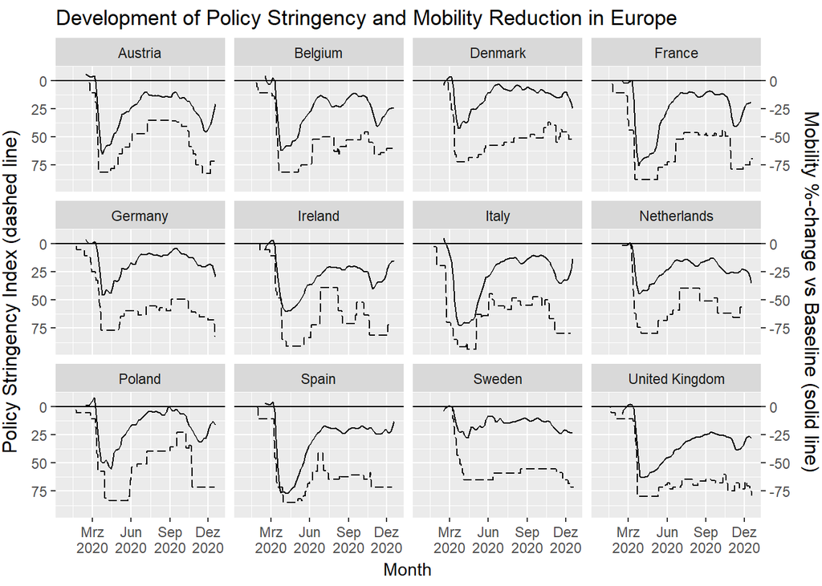

# Variation in Policy-Compliance

In order to build our model, we can make a preliminary, bivariate analysis that shows the variance of policy compliance across different European countries.

For this analysis, policy-compliance is approximated as the difference between the level of policy-stringency and the observed reduction in mobility.

`Compliance = 100 - (Policy Stringency Index - %-change in Mobility)`

The boxplot shows us that, indeed, the levels of policy compliance among European countries differ.

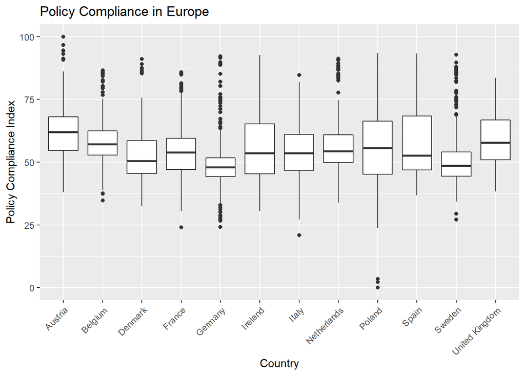

Additionally, as we want to assess the change of policy compliance across time in Europe, we can fit a linear regression line to the compliance data. This shows us that in all of the European countries analyzed, compliance with mobility-reducing-policies has reduced.

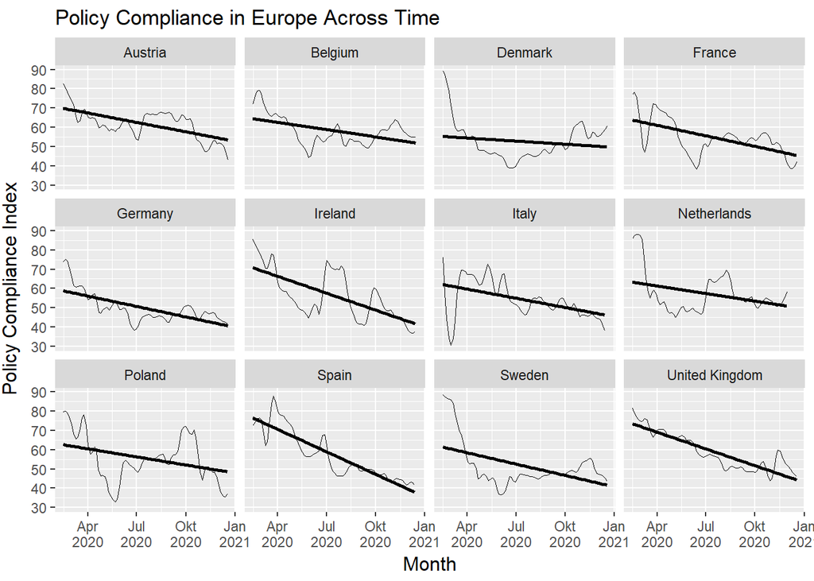

# Modelling

## Linear Non-Hierachical Model

`Compliance Index = β₀ + β₁ × Date + β₂ × Country + β₃ × Publicity + β₄ × Cases per 100.000 per 14 days + ε`

Regression Table

|  | Model 1 |
| --- | --- |
| Intercept | **1380.70** (115.51)*** |
| Date | **-0.07** (0.01)*** |
| Publicity | -0.01 (0.02) |
| Cases/100,000/14 Days | 0.00 (0.00) |
| Belgium | -3.21 (2.12) |
| Denmark | **-8.29** (2.12)*** |
| France | **-7.15** (2.11)*** |
| Germany | **-11.06** (2.12)*** |
| Ireland | -4.07 (2.13) |
| Italy | **-8.12** (2.17)*** |
| Netherlands | -2.97 (2.14) |
| Poland | **-5.67** (2.17)** |
| Spain | **-4.79** (2.24)* |
| Sweden | **-9.53** (2.11)*** |
| United Kingdom | -3.25 (2.13) |
| R<sup>2</sup> | 0.31 |
| Adj. R<sup>2</sup> | 0.29 |
| Num. obs. | 520 |

p < 0.001; p < 0.01; p < 0.05

| Variable | Coefficient | Std. Error | p-value |
| --- | --- | --- | --- |
| Stringency Index | -7.045e-01 | 9.107e-03 | < 2e-16 *** |
| Date | 6.122e-02 | 1.993e-03 | < 2e-16 *** |
| Belgium | 2.463e+00 | 8.466e-01 | 0.003649 ** |
| Denmark | 1.066e+01 | 8.430e-01 | < 2e-16 *** |
| France | 5.306e+00 | 8.474e-01 | 4.25e-10 *** |
| Germany | 1.208e+01 | 8.445e-01 | < 2e-16 *** |
| Ireland | 2.999e+00 | 8.523e-01 | 0.000439 *** |
| Italy | 5.026e+00 | 8.544e-01 | 4.39e-09 *** |
| Netherlands | 5.089e+00 | 8.564e-01 | 3.09e-09 *** |
| Poland | 7.011e+00 | 8.443e-01 | < 2e-16 *** |
| Spain | 2.109e+00 | 8.523e-01 | 0.013401 * |
| Sweden | 1.117e+01 | 8.431e-01 | < 2e-16 *** |
| United Kingdom | -2.997e-01 | 8.499e-01 | 0.724393 |

# References

“COVID-19 Community Mobility Report.” 2020. Google LLC. https://www.google.com/covid19/mobility?hl=en-GB.

Hale, Thomas, Noam Angrist, Emily Cameron-Blake, Laura Hallas, Beatriz Kira, Saptarshi Majumdar, Anna Petherick, Toby Phillips, Helen Tatlow, and Samuel Webster. 2020. “Oxford COVID-19 Government Response Tracker.” Blavatnik School of Government. https://www.bsg.ox.ac.uk/research/research-projects/coronavirus-government-response-tracker.